# COSC-635: Lab 3

**Daniel Carter**

[Notebook Link](https://colab.research.google.com/drive/1XQD5MjbsQ_vawl8TvTwmTmDfR3u5eVvJ?usp=sharing)

## Getting Started

Follow the instructions below to copy this notebook and to perform some initial setup.

1. Copy this notebook by selecting `File > Save a copy in Drive`.
2. A new window should open for the copied notebook. Move the new notebook to your course folder in Google Drive by selecting `File > Move` and then selecting the desired folder.
3. Update the name of the notebook by removing "Copy of" and replacing "Username" with your actual username.
4. Update the first cell in the notebook by specifying your course number (435 or 635) and by replacing "Student Name" with your actual name.
5. Do not edit the line that says `PLACEHOLDER_FOR_NOTEBOOK_LINK`. This will be used by the [notebook renderer](https://colab.research.google.com/drive/1CJTipys46ldZxJFwnt7XbdjQUfkmoXeU?usp=sharing) tool to insert a link to your Colab notebook.
6. Enable link sharing for your notebook.

## Preparing the Colab Environment

Run the cell below to install gymnasium and to download rltools to the virtual machine.

```python
%%capture
!pip install gymnasium==0.28.1
!rm rltools -r
!git clone https://github.com/drbeane/rltools.git
```

The cell below includes the import statements that you will need for this assignmnet. No other import statements should be added anywhere in the notebook.

```python
import pandas as pd
import numpy as np
import matplotlib.pyplot as plt
import time

import rltools
import rltools.gym as gym
from rltools.utils import evaluate, create_gif
from rltools.dynamic_prog import DPAgent
from rltools.monte_carlo import MCAgent
from rltools.temp_diff import TDAgent
from gymnasium.envs.toy_text.frozen_lake import generate_random_map
```

## Note on Variable Names

You are free to select the variable names for the objects that you create in this notebook. But please make sure that the variable names you select in each part are distinct from those in other parts. An exception to this rule can be made in instances where a particular variable will be used in a single cell, but no where else in the notebook.

# Part 1 - Frozen Lake

In Part 1 of this assignment, you will apply a variety of control methods to the Frozen Lake environment. In particular, you will apply value iteration, Monte Carlo control, and Q-learning.

## 1.A - Create Environment

In the cell below, we create an 16x16 instance of the Frozen Lake environment. You can rename this environment, if you wish. Otherwise, run this cell as-is.

[figure not shown]

```python
env1 = gym.make(
    'FrozenLake-v1',
    prob = 0.9,
    rew_struct = [-0.2, -10, 100],
    desc = generate_random_map(size=16, p=0.8, seed=8),
    render_mode = 'rgb_array'
)

state, info = env1.reset()
plt.imshow(env1.render())
plt.axis('off')
plt.show()
```

## 1.B - Value Iteration

Complete the following steps in the cell below:

1. Create an instance of `DPAgent` for the environment from 1A. Set a discount rate of 1.0 and a seed of 1.
2. Use the agent to perform value iteration.
3. Use `evaluate()` to evaluate the optimal policy. Use 1000 episodes, `gamma=1.0`, `seed=1`, and `check_success=True`.

```python
dp_agent = DPAgent(env1, gamma=1.0, seed=1)
dp_agent.value_iteration()
evaluate(env1, dp_agent, episodes=1000, gamma=1.0, seed=1, check_success=True)
```

```
Value iteration required 328 steps to converge.
Mean Return:    83.519
StdDev Return:  25.3604
Mean Length:    51.505
StdDev Length:  19.0058
Success Rate:   0.942
```

```
{'mean_return': 83.51899999999985,
 'stdev_return': 25.360355656023405,
 'mean_length': 51.505,
 'stdev_length': 19.005787934205728,
 'sr': 0.942,
 'avg_len_s': 52.28662420382165,
 'avg_len_f': 38.810344827586206}
```

## 1.C - Monte Carlo Control

Create an instance of `MCAgent` for `env1` with `gamma=1.0`. Then apply Monte Carlo control. Guidelines for the parameter selection are provided below.

- Use 20,000 to 50,000 episodes. The fewer required to get the desired performance, the better.
- Set `max_steps` to 500.
- Experiment with `alpha`, `alpha_decay`, `epsilon`, and `epsilon_decay`.
- Set `exploring_starts=True`.
- Set a seed value for the sake of reproducability.
- Display an update every 1000 episodes.
- Use 1000 episodes for evaluation.
- Set `check_success=True`.

Your goal is to find a policy with a success rate of at least 0.8, but you are encouraged to try to do even better, if possible. Note that the optimal policy found by value iteration had a success rate of around 0.94.

```python
mc_agent1 = MCAgent(env1, gamma=1.0)
mc_agent1.control(
    episodes=40000,
    max_steps=500,
    alpha=0.001,
    alpha_decay=1e-4,
    epsilon=1.0,
    epsilon_decay=1e-4,
    exploring_starts=True,
    updates = 1000,
    eval_eps = 1000,
    check_success=True,
    seed=1
)
```

```
Episode   Mean[Return]  SD[Return]  Mean[Length]  SD[Length]  Success_Rate
--------------------------------------------------------------------------
1000          -13.9972      3.7650       20.9860     18.8252        0.0000  (Saving new best model)
2000          -13.9362      4.3468       20.6810     21.7339        0.0000
3000          -13.5816      3.6285       18.9080     18.1426        0.0000  (Saving new best model)
4000          -47.4850     25.7869      191.5610    135.7012        0.0000
5000          -52.5058     25.4195      217.0570    134.1259        0.0000
6000          -16.2536     13.0477       34.4570     65.7525        0.0030
7000          -47.1710     62.4557      365.0510    147.2046        0.2880
8000          -13.9202      4.1671       20.6010     20.8353        0.0000
9000          -13.8590      3.9407       20.2950     19.7034        0.0000
10000          67.5278     36.9223       95.7110     55.1508        0.8770  (Saving new best model)
11000          61.1624     39.0921      115.4380     56.4313        0.8550
12000          60.2966     40.4796      113.1670     56.7183        0.8430
13000          58.2920     41.9125      116.5900     60.4868        0.8310
```

[output cut: 27 more lines]

## 1.D - Evaluating Monte Carlo Policy

Use `evaluate()` to evaluate the policy found by the Monte Carlo agent. Use 1000 episodes, `gamma=1.0`, `seed=1`, and `check_success=True`.

**If your agent does not have a success rate of at least 0.8, then you should adjust the parameters from 1.E and retrain the agent.**

```python
results = evaluate(env1, mc_agent1, episodes=1000, gamma=1.0, seed=1, check_success=True)
results
```

```
Mean Return:    75.1864
StdDev Return:  38.6972
Mean Length:    36.518
StdDev Length:  19.0
Success Rate:   0.839
```

```
{'mean_return': 75.1863999999999,
 'stdev_return': 38.69721508119152,
 'mean_length': 36.518,
 'stdev_length': 19.000044105211966,
 'sr': 0.839,
 'avg_len_s': 40.61978545887962,
 'avg_len_f': 15.142857142857142}
```

## 1.E - Q-Learning

Create an instance of `TDAgent` for the environment from 1.A, setting `gamma=1.0`. Then apply Q-learning. Use the same guidelines for parameter selection as those described for Monte Carlo control in Step 1.C. You do not need to use the exact same parameters, however.

Your goal is to find a policy with a success rate of at least 0.9, but you are encouraged to try to do even better, if possible. Note that the optimal policy found by value iteration had a success rate of around 0.94

```python
td_agent1 = TDAgent(env1, gamma=1.0)
td_agent1.q_learning(
    episodes=20000,
    max_steps=500,
    alpha=0.1,
    alpha_decay=1e-4,
    epsilon=1.0,
    epsilon_decay=1e-3,
    exploring_starts=True,
    updates = 1000,
    eval_eps = 1000,
    check_success=True,
    seed=1
)
```

```
Episode   Mean[Return]  SD[Return]  Mean[Length]  SD[Length]  Success_Rate
--------------------------------------------------------------------------
1000          -13.9618      4.0168       20.8090     20.0842        0.0000  (Saving new best model)
2000          -65.5690     34.3197      296.9700    186.5468        0.0040
3000           33.2052     54.5810       70.4240     33.5261        0.5190
4000           82.8052     26.5738       51.7740     19.4563        0.9360  (Saving new best model)
5000           83.0158     26.0881       52.3710     19.8116        0.9390  (Saving new best model)
6000           82.7488     26.1789       53.1560     20.3535        0.9380
7000           82.4416     27.3215       51.3920     19.3484        0.9320
8000           83.4478     25.8626       50.7610     18.7136        0.9400  (Saving new best model)
9000           81.8572     27.9278       52.6640     21.3615        0.9290
10000          82.4872     26.6180       52.8140     20.0220        0.9350
11000          83.6028     24.9486       52.1860     19.7052        0.9440  (Saving new best model)
12000          80.8236     29.7352       52.3320     20.0442        0.9190
13000          82.8890     26.1427       53.0050     21.1419        0.9390
14000          82.9292     26.0756       52.2540     20.7903        0.9380
15000          84.8212     22.0791       53.2440     20.0708        0.9570  (Saving new best model)
16000          83.6220     24.9920       52.0900     20.4956        0.9440
17000          81.9892     27.9759       52.0040     20.1489        0.9290
18000          84.0894     23.8377       53.0530     19.1577        0.9500
19000          83.7596     24.9034       51.9520     18.9441        0.9450
20000          81.4920     28.9336       51.1900     19.5164        0.9230
```

## 1.F - Evaluating Q-Learning Policy

Use `evaluate()` to evaluate the policy found by the TD agent. Use 1000 episodes, `gamma=1.0`, `seed=1`, and `check_success=True`.

**If your agent does not have a success rate of at least 0.9, then you should adjust the parameters from 1.E and retrain the agent.**

```python
results = evaluate(env1, td_agent1, episodes=1000, gamma=1.0, seed=1, check_success=True)
results
```

```
Mean Return:    82.2158
StdDev Return:  27.6768
Mean Length:    51.421
StdDev Length:  19.03
Success Rate:   0.93
```

```
{'mean_return': 82.21579999999987,
 'stdev_return': 27.676831291894633,
 'mean_length': 51.421,
 'stdev_length': 19.03002256961352,
 'sr': 0.93,
 'avg_len_s': 52.30537634408602,
 'avg_len_f': 39.67142857142857}
```

# Part 2 - Cart Pole Environment

In Part 2, you will apply Monte Carlo control and Q-Learning to the Cart Pole environment. This environment has a continuous state space, so we will need to discretize the state space to use these algorithms. Note that we do not have direct access to the MDP for the discretized version of this environment, so we cannot apply value iteration to find the optimal policy.

## 2.A - Create Environment

The cell below creates an instance of the Cart Pole environment in which the state coordinates are discretized by splitting them each across 25 bins. You can rename this environment, if you wish. Otherwise, run this cell as-is.

```python
env2 = gym.make(
    "CartPole-v1", num_bins=25,
    render_mode='rgb_array',
)
```

## 2.B - Monte Carlo Control

Create an instance of `MCAgent` for the environment from 2.A with `gamma=1.0`. Then apply Monte Carlo control. Guidelines for the parameter selection are provided below.

- Use 20,000 to 50,000 episodes. The fewer required to get the desired performance, the better.
- Set `max_steps` to 1000.
- Experiment with `alpha`, `alpha_decay`, `epsilon`, and `epsilon_decay`.
- Set `exploring_starts=False`.
- Set a seed value for the sake of reproducability.
- Display an update every 1000 episodes.
- Use 100 episodes for evaluation.
- Set `check_success=False`.

Your goal is to find a policy that satisfies the following two criteria:

- `Mean[Return] > 500`
- `Mean[Return] - SD[Return] > 250`

**Note: It is possible to meet (and considerably exceed) this goal in 20,000 episodes.**

```python
mc_agent2 = MCAgent(env2, gamma=1.0)
mc_agent2.control(
    episodes=20000,
    max_steps=1000,
    alpha=0.1,
    alpha_decay=1e-4,
    epsilon=1.0,
    epsilon_decay=1e-4,
    exploring_starts=False,
    updates = 1000,
    eval_eps = 100,
    check_success=False,
    seed=1
)
```

```
Episode   Mean[Return]  SD[Return]  Mean[Length]  SD[Length]
------------------------------------------------------------
1000          127.3000     53.6473      128.3000     53.6473  (Saving new best model)
2000          131.0300     38.3115      132.0300     38.3115  (Saving new best model)
3000          135.7300     35.1912      136.7300     35.1912  (Saving new best model)
4000          264.2800    162.1722      265.2600    162.0815  (Saving new best model)
5000          144.8800     40.1533      145.8800     40.1533  (Saving new best model)
6000          488.3200    299.6357      489.1700    299.3797  (Saving new best model)
7000          268.0100    143.3516      269.0100    143.3516
8000          507.2400    276.0282      508.0900    275.7605  (Saving new best model)
9000          724.8700    300.4978      725.4700    300.1318  (Saving new best model)
10000         794.5000    303.2289      794.9200    302.8360  (Saving new best model)
11000         919.9400    215.8025      920.0800    215.4835  (Saving new best model)
12000         676.0900    335.1163      676.6700    334.7104
13000         970.2000    109.6323      970.3100    109.3906  (Saving new best model)
14000         691.5900    333.2637      692.1400    332.8474
15000         954.1600    161.6701      954.2500    161.4122
16000         944.5800    178.3841      944.6900    178.1076
17000         261.4800    173.6379      262.4800    173.6379
18000         225.7400     70.2982      226.7400     70.2982
19000         513.1000    253.3347      513.9700    253.0849
20000         907.2800    218.5412      907.4700    218.1976
```

## 2.C - Evaluating Monte Carlo Policy

Use `evaluate()` to evaluate the policy found by the Monte Carlo agent. Use 500 episodes, `gamma=1.0`, `seed=1`, `max_steps=1000`, and `check_success=False`.

```python
results = evaluate(env2, mc_agent2, episodes=500, gamma=1.0, seed=1, max_steps=1000, check_success=False)
results
```

```
Mean Return:    960.298
StdDev Return:  136.0015
Mean Length:    960.406
StdDev Length:  135.7412
```

```
{'mean_return': 960.298,
 'stdev_return': 136.00153380017446,
 'mean_length': 960.406,
 'stdev_length': 135.7412434155515}
```

## 2.D - Animate an Episode using MC Policy

Use the `create_gif()` function to animate an episode following the policy found by the MC Agent. Store the gif in a folder named `gifs` and name the gif `cartpole_01`. Leave `max_steps` at the default value of 1000. Set a seed for the episode. Adjust the seed until you find an episode with a length of at least 500 steps.

```
544 steps completed.
Cumulative reward: 543.0
```

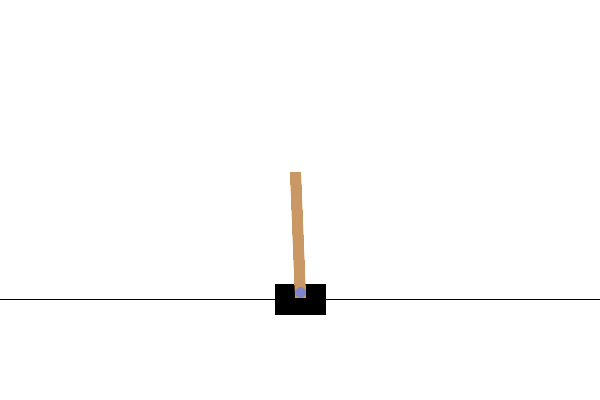

```python
create_gif(env2, mc_agent2, max_steps=1000, seed=1, folder='gifs', filename='cartpole_01')
```

## 2.E - Q-Learning

Create an instance of `TDAgent` for the environment from 2.A, setting `gamma=1.0`. Use the agent to apply Q-learning. Use the same guidelines for parameter selection as those described for Monte Carlo control in Step 2.B. You do not need to use the exact same parameters, however.

Your goal is to find a policy that satisfies the following criteria:

- `Mean[Return] - SD[Return] > 950`

**Note: It is possible to meet this goal in 20,000 episodes. Perfect performance can be obtained in as few as 13,000 episodes with the right parameters.**

```python
td_agent2 = TDAgent(env2, gamma=1.0)
td_agent2.q_learning(
    episodes=20000,
    max_steps=1000,
    alpha=0.2,
    alpha_decay=5e-6,
    epsilon=1.0,
    epsilon_decay=5e-4,
    exploring_starts=False,
    updates = 1000,
    eval_eps = 100,
    check_success=False,
    seed=1
)
```

```
Episode   Mean[Return]  SD[Return]  Mean[Length]  SD[Length]
------------------------------------------------------------
1000          111.7600     38.8958      112.7600     38.8958  (Saving new best model)
2000          121.8100     26.6757      122.8100     26.6757  (Saving new best model)
3000          156.1100     50.6399      157.1100     50.6399  (Saving new best model)
4000          139.4600     36.9793      140.4600     36.9793
5000          277.5400    184.4948      278.5000    184.3382
6000          470.0700    301.4346      470.9100    301.1534  (Saving new best model)
7000          248.0800    104.4557      249.0800    104.4557
8000          816.5400    264.2531      816.9400    263.8367  (Saving new best model)
9000          268.6400    190.8454      269.6200    190.7687
10000         925.2800    203.9833      925.4100    203.6646  (Saving new best model)
11000         966.8600    127.3288      966.9300    127.0868  (Saving new best model)
12000         959.6800    144.2453      959.7600    143.9881
13000         934.3700    188.1261      934.5100    187.8261
14000         945.3500    173.6703      945.4700    173.3935
15000         930.0300    202.6505      930.1700    202.3537
16000        1000.0000      0.0000     1000.0000      0.0000  (Saving new best model)
17000        1000.0000      0.0000     1000.0000      0.0000
18000        1000.0000      0.0000     1000.0000      0.0000
19000         987.4300     88.5531      987.4500     88.4140
20000         992.1700     48.9293      992.2100     48.7759
```

## 2.F - Evaluating Q-Learning Policy

Use `evaluate()` to evaluate the policy found by the TD agent. Use 500 episodes, `gamma=1.0`, `seed=1`, `max_steps=1000`, and `check_success=False`.

```python
results = evaluate(env2, td_agent2, episodes=500, gamma=1.0, seed=1, max_steps=1000, check_success=False)
results
```

```
Mean Return:    999.04
StdDev Return:  21.4448
Mean Length:    999.042
StdDev Length:  21.4001
```

```
{'mean_return': 999.04,
 'stdev_return': 21.44477558754113,
 'mean_length': 999.042,
 'stdev_length': 21.400098971733758}
```

## 2.G - Animate an Episode using TD Policy

Use the `create_gif()` function to animate an episode following the policy found by the TD Agent. Store the gif in a folder named `gifs` and name the gif `cartpole_02`. Leave `max_steps` at the default value of 1000. Set a seed for the episode. Adjust the seed until you find an episode with a length of at least 950 steps.

```
1000 steps completed.
Cumulative reward: 1000.0
```

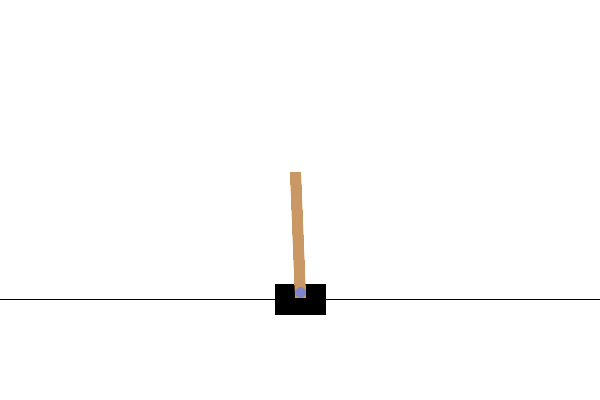

```python
create_gif(env2, td_agent2, max_steps=1000, seed=1, folder='gifs', filename='cartpole_02')
```

# Submission Instructions

1. Perform a Restart and Run All by clicking **Runtime > Restart session and run all**.
2. Copy the link to your notebook by clicking **Share > Copy Link**.
3. Paste the copied link into the `notebook_url` field in the [Notebook Renderer](https://colab.research.google.com/drive/1CJTipys46ldZxJFwnt7XbdjQUfkmoXeU?usp=sharing) tool and then execute the cell to render the notebook.
4. The Notebook Renderer will open up a save file dialog. Save the resulting HTML file yo your local machine.
5. Submit the HTML file to Canvas.